# Rotational Symmetry

Rotation Groups — Simple Visual Examples

Change

Canonical Movements

Immunity

Groups

Published

July 26, 2026

Modified

November 22, 2026

## Rotational Symmetry

Assume we have a plane 2D geomtric shape on the table. How would we rotate it with our hand? Two fingers: the thumb to **anchor** the rotation, and one other finger to rotate the object. Where would you place the thumb? On the point where you imagine the **axis of rotation** to be; an imaginary line rising *vertically* from the surface. And the other finger would be placed *on the periphery* of the object. This is your repeatable **canonical movement** in this instance.

How do we describe this with math? Two ways. A `set`, and a `matrix`.

### Cyclic Symmetry Group

A **`cyclic symmetry group`** is a `set` $\mathbb{C}_{𝑛}$ contains the symmetries produced by repeatedly applying one basic rotation. For a 2D object, it has $n$ elements: the identity plus $n−1$ rotations by multiples of $360^\circ /n$. So what does this `set` contain?

$$\mathbb{C}_{𝑛} = \{ {e,r,r^2,…,r^{n−1}} \}
\tag{1}$$

where:

- $e$ is the identity operator: “do nothing.”
- $r$ is one basic rotation, usually by $360^\circ /n$
- $r^k$ means applying that rotation $k$ times, equivalent to rotating by $k \times 360^\circ /n$
- $r^n = e$ because $n$ repetitions return the object to its starting position.

### A Rotation Matrix

If we had a set of 2D points ${x,y}$ then we can write their rotation as a transformation of their coordinates to a new position, representing a rotation **about a notional axis of rotation**. What might such an axis look like?

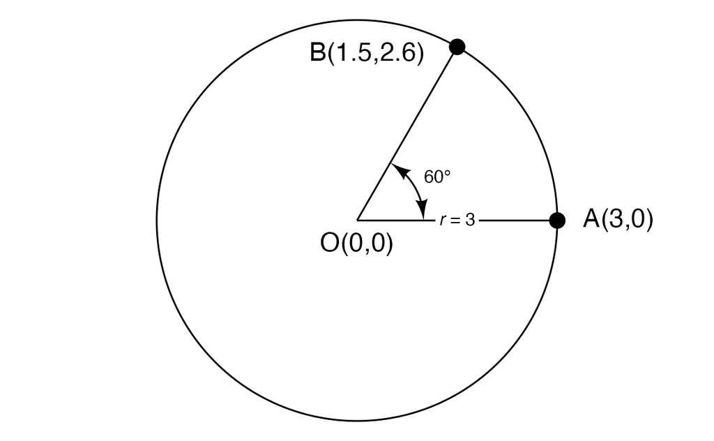

Figure 1: Rotation Matrix calculations

We rotate point $A$ about the origin $O$ and obtain $B$. And we transform the original coordinates of A to those of B, using a matrix multiplication:

$$\begin{pmatrix}
x_B \\
y_B
\end{pmatrix}
=
\begin{pmatrix}
\cos 60^\circ & -\sin 60^\circ \\
\sin 60^\circ & \cos 60^\circ
\end{pmatrix}
\begin{pmatrix}
x_A \\
y_A
\end{pmatrix}
\tag{2}$$

so:

$$x_B = x_A \cos 60^\circ - y_A \sin 60^\circ, \qquad
y_B = x_A \sin 60^\circ + y_A \cos 60^\circ$$
## Wait, But Why?

## Design Notes

- **Rotational only** ($\mathbb{Z}_{n}$): swirling, pinwheel-like, no mirror lines.
- **Reflection only** ($\mathbb{R}_{𝑛} = \{ {e,m} \}$: bilateral balance (faces, logos, architecture).
- **Dihedral** ($\mathbb{D}_{n}$ ): the most common decorative symmetry (snowflakes, flowers, rose windows, tiles).

These geometric ideas become the constraints we later impose on iterative and random processes.